# Lab #2 - Gapminder Dataset

Econ 224

August 30th, 2018

# Introduction

Today we’ll revisit the `gapminder` dataset and use it to introduce some more advanced features of `dplyr` and `ggplot2`, building on the material from our first lab. Before you begin, make sure that you have loaded the `tidyverse` and `gapminder` packages.

# Faceting - Plotting multiple subsets at once

Let’s pick up where we left off in lab #1, with a plot of GDP per capita and life expectancy in 2007:

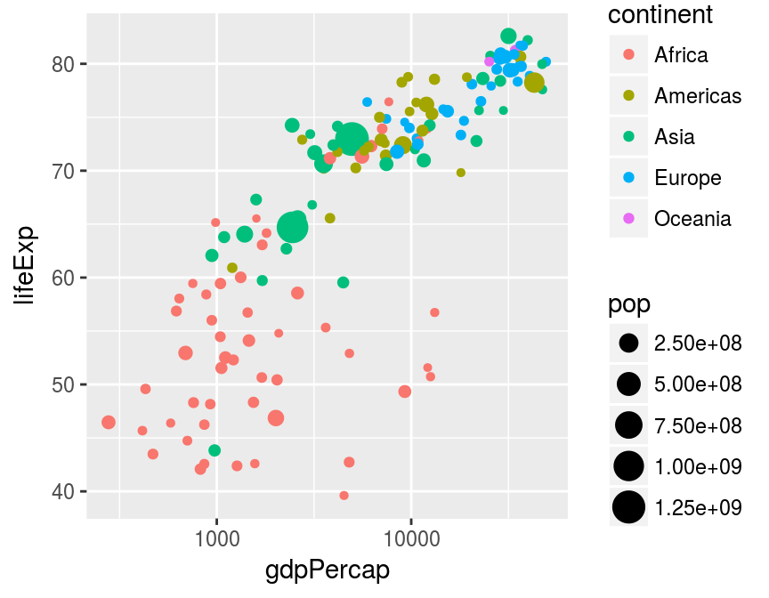

```r
gapminder_2007 <- gapminder %>%
  filter(year == 2007)
ggplot(gapminder_2007) +
  geom_point(aes(x = gdpPercap, y = lifeExp, color = continent, size = pop)) +
  scale_x_log10()
```

This is an easy way to make a plot for a single year. But what if you wanted to make the same plot for *every year* in the `gapminder` dataset? It would take a lot of copying-and-pasting of the preceding code chunk to accomplish this. Fortunately there’s a much easier way: *faceting*. In `ggplot2` a *facet* is a subplot that corresponds to a subset of your dataset, for example the year 2007. We’ll now use faceting to reproduce the plot from above for all the years in `gapminder` simultaneously:

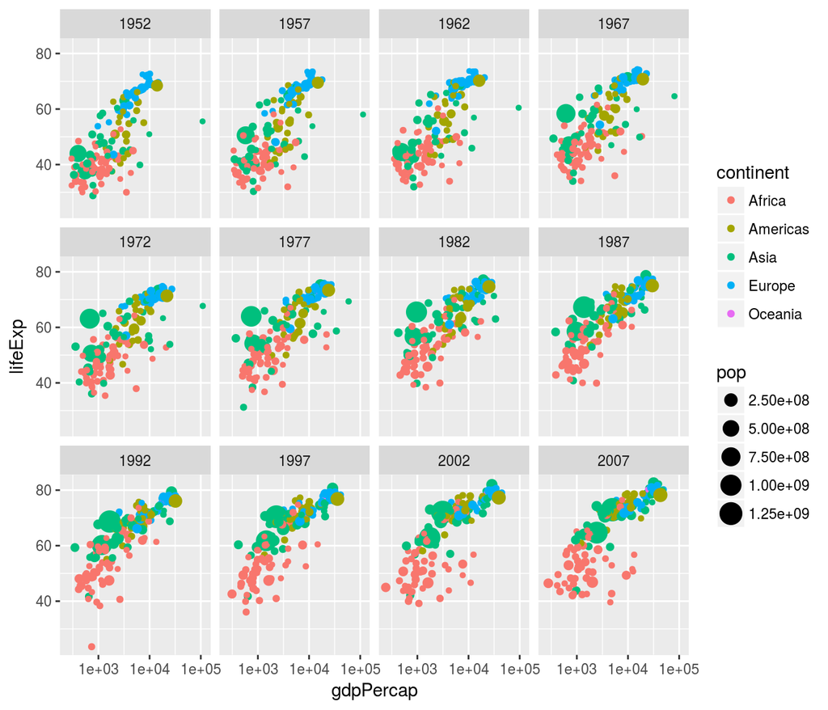

```r
ggplot(gapminder) +
  geom_point(aes(x = gdpPercap, y = lifeExp, color = continent, size = pop)) +
  scale_x_log10() +
  facet_wrap(~ year)
```

Note the syntax here: in a similar way to how we added `scale_x_log10()` to plot on the log scale, we add `facet_wrap(~ year)` to facet by `year`. The tilde `~` is important: this has to precede the variable by which you want to facet.

Now that we understand how to produce it, let’s take a closer look at this plot. Notice how this plot allows us to visualize five variables *simultaneously*. By looking at how the plots change over time, we see a pattern of increasing GDP per capita and life expectancy throughout the world between 1952 and 2007. Notice in particular the dramatic improvements in both variables in the Asian economies.

# Exercise #1

1. What would happen if I were to run the following code? Explain briefly.

```r
ggplot(gapminder_2007) +
  geom_point(aes(x = gdpPercap, y = lifeExp, color = continent, size = pop)) +
  scale_x_log10() +
  facet_wrap(~ year)
```

2. Make a scatterplot with data from `gapminder` for the year 1977. Your plot should be faceted by continent with GDP per capita on the log scale on the x-axis, life expectancy on the y-axis, and population indicated by the size of each point.
3. What would happen if you tried to facet by `pop`? Explain briefly.

# Solution to Exercise #1

*Write your code and solutions here*

1. We’ll only get one facet since the tibble `gapminder_2007` only has data for 2007:

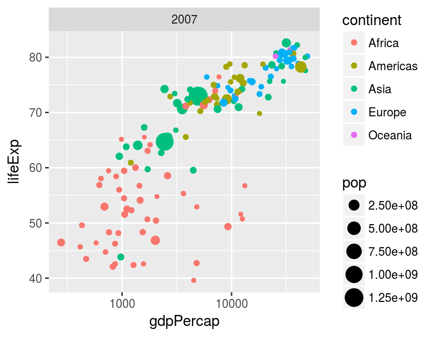

```r
ggplot(gapminder_2007) +
  geom_point(aes(x = gdpPercap, y = lifeExp, color = continent, size = pop)) +
  scale_x_log10() +
  facet_wrap(~ year)
```

2. Use the following code:

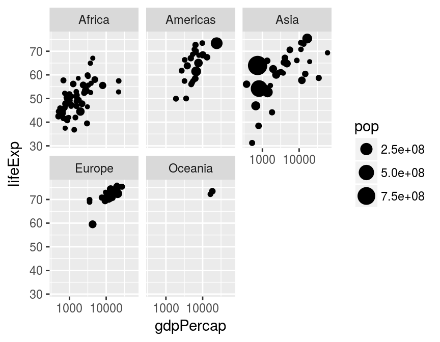

```r
gapminder_1977 <- gapminder %>%
  filter(year == 1977)
ggplot(gapminder_1977) +
  geom_point(aes(x = gdpPercap, y = lifeExp, size = pop)) +
  scale_x_log10() +
  facet_wrap(~ continent)
```

3. You’ll get something crazy if you try this. Population is continuous rather than categorical so every country has a different value for this variable. You’ll end up with one plot for every country, containing a single point:

```r
# Not run: it takes a long time and looks nasty!
gapminder_1977 <- gapminder %>%
  filter(year == 1977)
ggplot(gapminder_1977) +
  geom_point(aes(x = gdpPercap, y = lifeExp, color = continent)) +
  scale_x_log10() +
  facet_wrap(~ pop)
```

# `dplyr` verbs

For the next few sections we’ll take a short break from `ggplot2` and turn our attention to `dplyr`. In lab #1 we learned about the pipe, `%>%`, and two `dplyr` functions: `filter()` and `arrange()`. In the parlance of the `dplyr` documentation, these are called “verbs.” In `dplyr` we use `%>%` to combine these verbs in various ways to manipulate a tibble. In this section and the following two, we’ll learn three more `dplyr` verbs: `select`, `summarize` and `group_by`.

# The `select` verb

```r
gapminder %>% select(pop)
```

```
# A tibble: 1,704 x 1
        pop
      <int>
 1  8425333
 2  9240934
 3 10267083
 4 11537966
 5 13079460
 6 14880372
 7 12881816
 8 13867957
 9 16317921
10 22227415
# ... with 1,694 more rows
```

To display only `pop`, `country`, and `year`, use the following:

```r
gapminder %>% select(pop, country, year)
```

```
# A tibble: 1,704 x 3
        pop country      year
      <int> <fct>       <int>
 1  8425333 Afghanistan  1952
 2  9240934 Afghanistan  1957
 3 10267083 Afghanistan  1962
 4 11537966 Afghanistan  1967
 5 13079460 Afghanistan  1972
 6 14880372 Afghanistan  1977
 7 12881816 Afghanistan  1982
 8 13867957 Afghanistan  1987
 9 16317921 Afghanistan  1992
10 22227415 Afghanistan  1997
# ... with 1,694 more rows
```

Now suppose that we wanted to select every column *except* `pop`. Here’s one way to do it:

```r
gapminder %>% select(country, continent, year, lifeExp, gdpPercap)
```

```
# A tibble: 1,704 x 5
   country     continent  year lifeExp gdpPercap
   <fct>       <fct>     <int>   <dbl>     <dbl>
 1 Afghanistan Asia       1952    28.8      779.
 2 Afghanistan Asia       1957    30.3      821.
 3 Afghanistan Asia       1962    32.0      853.
 4 Afghanistan Asia       1967    34.0      836.
 5 Afghanistan Asia       1972    36.1      740.
 6 Afghanistan Asia       1977    38.4      786.
 7 Afghanistan Asia       1982    39.9      978.
 8 Afghanistan Asia       1987    40.8      852.
 9 Afghanistan Asia       1992    41.7      649.
10 Afghanistan Asia       1997    41.8      635.
# ... with 1,694 more rows
```

but that takes a lot of typing! If there were more than a handful of columns in our tibble it would be very difficult to *deselect* a column in this way. Fortunately there’s a shortcut: use the minus sign

```r
gapminder %>% select(-pop)
```

```
# A tibble: 1,704 x 5
   country     continent  year lifeExp gdpPercap
   <fct>       <fct>     <int>   <dbl>     <dbl>
 1 Afghanistan Asia       1952    28.8      779.
 2 Afghanistan Asia       1957    30.3      821.
 3 Afghanistan Asia       1962    32.0      853.
 4 Afghanistan Asia       1967    34.0      836.
 5 Afghanistan Asia       1972    36.1      740.
 6 Afghanistan Asia       1977    38.4      786.
 7 Afghanistan Asia       1982    39.9      978.
 8 Afghanistan Asia       1987    40.8      852.
 9 Afghanistan Asia       1992    41.7      649.
10 Afghanistan Asia       1997    41.8      635.
# ... with 1,694 more rows
```

Just as we could when *selecting*, we can *deselect* multiple columns by separating their names with a comma:

```r
gapminder %>% select(-pop, -year)
```

```
# A tibble: 1,704 x 4
   country     continent lifeExp gdpPercap
   <fct>       <fct>       <dbl>     <dbl>
 1 Afghanistan Asia         28.8      779.
 2 Afghanistan Asia         30.3      821.
 3 Afghanistan Asia         32.0      853.
 4 Afghanistan Asia         34.0      836.
 5 Afghanistan Asia         36.1      740.
 6 Afghanistan Asia         38.4      786.
 7 Afghanistan Asia         39.9      978.
 8 Afghanistan Asia         40.8      852.
 9 Afghanistan Asia         41.7      649.
10 Afghanistan Asia         41.8      635.
# ... with 1,694 more rows
```

# Exercise #2

1. Select only the columns `year`, `lifeExp`, and `country` in `gapminder`.
2. Select all the columns *except* `year`, `lifeExp`, and `country` in `gapminder`.

# Solution to Exercise #2

*Write your code and solutions here*

1. Use the following:

```r
gapminder %>% select(year, lifeExp, country)
```

```
# A tibble: 1,704 x 3
    year lifeExp country
   <int>   <dbl> <fct>
 1  1952    28.8 Afghanistan
 2  1957    30.3 Afghanistan
 3  1962    32.0 Afghanistan
 4  1967    34.0 Afghanistan
 5  1972    36.1 Afghanistan
 6  1977    38.4 Afghanistan
 7  1982    39.9 Afghanistan
 8  1987    40.8 Afghanistan
 9  1992    41.7 Afghanistan
10  1997    41.8 Afghanistan
# ... with 1,694 more rows
```

2. Use the following:

```r
gapminder %>% select(-year, -lifeExp, -country)
```

```
# A tibble: 1,704 x 3
   continent      pop gdpPercap
   <fct>        <int>     <dbl>
 1 Asia       8425333      779.
 2 Asia       9240934      821.
 3 Asia      10267083      853.
 4 Asia      11537966      836.
 5 Asia      13079460      740.
 6 Asia      14880372      786.
 7 Asia      12881816      978.
 8 Asia      13867957      852.
 9 Asia      16317921      649.
10 Asia      22227415      635.
# ... with 1,694 more rows
```

# The `summarize` verb

Suppose we want to calculate the sample mean of the column `lifeExp` in `gapminder`. We can do this using the `summarize` verb as follows:

```r
gapminder %>% summarize(mean_lifeExp = mean(lifeExp))
```

```
# A tibble: 1 x 1
  mean_lifeExp
         <dbl>
1         59.5
```

Note the syntax: within `summarize` we have an *assignment statement*. In particular, we assign `mean(lifeExp)` to the variable `mean_lifeExp`. The key thing to know about `summarize` is that it always returns *collapses* a tibble with many rows into a single row. When we think about computing a sample mean, this makes sense: we want to summarize the column `lifeExp` as a single number. It doesn’t actually make much sense to compute the mean of `lifeExp` because this involves averaging over different countries *and* different years. Instead let’s compute the mean for a single year: 1952:

```r
gapminder %>%
  filter(year == 1952) %>%
  summarize(mean_lifeExp = mean(lifeExp))
```

```
# A tibble: 1 x 1
  mean_lifeExp
         <dbl>
1         49.1
```

We can use summarize to compute multiple summary statistics for a single variable, the same summary statistic for multiple variables, or both:

```r
gapminder %>%
  filter(year == 1952) %>%
  summarize(mean_lifeExp = mean(lifeExp),
            sd_lifeExp = sd(lifeExp),
            mean_pop = mean(pop))
```

```
# A tibble: 1 x 3
  mean_lifeExp sd_lifeExp  mean_pop
         <dbl>      <dbl>     <dbl>
1         49.1       12.2 16950402.
```

Note that if we *don’t* explicitly use an assignment statement, R will make up names for us based on the commands that we used:

```r
gapminder %>%
  filter(year == 1952) %>%
  summarize(mean(lifeExp), median(lifeExp), max(lifeExp))
```

```
# A tibble: 1 x 3
  `mean(lifeExp)` `median(lifeExp)` `max(lifeExp)`
            <dbl>             <dbl>          <dbl>
1            49.1              45.1           72.7
```